# HW02-P2 Adv Data Viz

## Instructions

**Task:** Open up the New York Times article [A Summer of Strikes](https://www.nytimes.com/interactive/2023/09/03/business/economy/strikes-union-sag-uaw.html), and scroll down to the plot titled “Union membership has fallen sharply over the past four decades (Share of the work force in a union, by industry)”.

[figure not shown]

Using `ggplot2` and other tools in R, recreate this plot. Note that you will need to create the data underlying the plot yourself. You can create this data in R with `tibble()`. You can also write the data in Excel or Google Sheets and export it as a CSV file.

**Requirements:**

- Overall
  - Panels for “All workers”, “By Sector”, and “By Industry” are shown.
  - Arrows showing the change from 1983 to 2022 are shown.
    - Note: be sure that the arrows all point in the correct direction!
  - The actual percentages in 1983 and 2022 are shown as text.
  - X-axis tick marks are at 0, 25, and 50.
  - Plot title says “Union membership has fallen sharply over the past four decades”.
  - Plot subtitle says “Share of the work force in a union, by industry”.
- Resource reflection
  - At least 1 resource is listed
  - At least 3 sentences about resources and their helpfulness in the task

**Bonus**: Additional possibilities to enhance your visualization include adjusting the default aesthetics of the arrows, aligning your plots neatly, and adding margins in order to left-align the y-axis text.

## Setup

```r
# Code for loading packages
library(tidyverse)
library(ggplot2)
library(grid)
library(showtext)
library(patchwork)
```

```r
# Code for generating the data (if using the tibble() approach)
unions <- tibble(group = c("All workers", "Private sector", "Public sector", "Transportation and utilities", "Manufacturing", "Mining", "Construction", "Education and health", "Arts, entertainment and recreation", "Business services", "Retail, food and hospitality", "Public administration", "Agriculture"),
       union_1983 = c(20, 17, 37, 47, 28, 27, 28, 26, 17, 10, 8, 30, 4),
       union_2022 = c(10, 6, 33, 16, 8, 7, 13, 17, 7, 3, 3, 28, 5),
       text_1983 = c("20%", "17", "37", "47", "28", "27", "28", "26", "17", "10", "8", "30", "4"),
       text_2022 = c("10%", "6", "33", "16", "8", "7", "13", "17", "7", "3", "3", "28", "5"))

# relevel groups so the order of industries matches the plot
unions <- unions %>%
  mutate(group = fct_relevel(group, "Agriculture", "Public administration", "Retail, food and hospitality", "Business services", "Arts, entertainment and recreation", "Education and health", "Construction", "Mining", "Manufacturing", "Transportation and utilities", "Public sector", "Private sector", "All workers",))
```

## Visualization

```r
# Code for recreating the visualization

# create industries subset for industries plot
industries <- unions |>
  filter(! group %in% c("All workers", "Private sector", "Public sector"))

# create industries w/o agriculture subset (for labeling)
industries_no_ag <- industries |>
  filter(group != "Agriculture")

# create ag industry subset (for labeling)
ag_industry <- industries |>
  filter(group == "Agriculture")

# create sectors subset for sectors plot
sectors <- unions |>
  filter(group %in% c("Private sector", "Public sector"))

# create all workers subset for all workers plot
all_workers <- unions |>
  filter(group == "All workers")
```

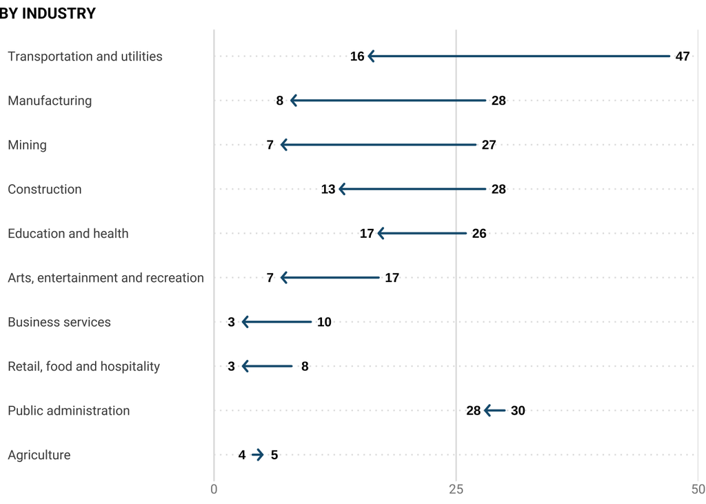

```r
# add Roboto font and turn on showtext for all subsequent plots
font_add_google("Roboto")
showtext_auto()

# create industries plot
industries_plot <- ggplot() +
  geom_segment(data = industries,
               aes(x = union_1983, xend = union_2022, y = group),
               arrow = arrow(angle = 50,
                             length = unit(0.17, "cm")),
               color = "#155c7e",
               linewidth = 0.75,
               lineend = "round") +
  geom_text(data = industries_no_ag,
            aes(x = union_1983 + 1.4, y = group, label = union_1983),
            size = 3.25,
            fontface = "bold") +
  geom_text(data = industries_no_ag,
            aes(x = union_2022 - 1.2, y = group, label = union_2022),
            size = 3.25,
            fontface = "bold") +
  geom_text(data = ag_industry,
            aes(x = union_2022 + 1.25, y = group, label = union_2022),
            size = 3.25,
            fontface = "bold") +
  geom_text(data = ag_industry,
            aes(x = union_1983 - 1.1, y = group, label = union_1983),
            size = 3.25,
            fontface = "bold") +
  scale_x_continuous(limits = c(0, 50),
                     breaks = c(0, 25, 50),
                     expand = c(0, 0)) +
  labs(title = "BY INDUSTRY") +
  theme(text = element_text(family = "Roboto"),
        plot.title = element_text(hjust = -0.556,
                                  size = 11,
                                  face = "bold"),
        axis.ticks = element_blank(),
        axis.title = element_blank(),
        axis.text.x = element_text(size = 9.25,
                                   color = "#848484"),
        axis.text.y = element_text(margin = margin(r = 7, unit = "pt"),
                                   hjust = 0,
                                   size = 9.25),
        axis.line.y = element_line(color = "#e1e1e1"),
        panel.background = element_blank(),
        panel.grid.major.x = element_line(color = "#e1e1e1"),
        panel.grid.major.y = element_line(color = "#e1e1e1",
                                          linewidth = 0.5,
                                          linetype = 3))

industries_plot
```

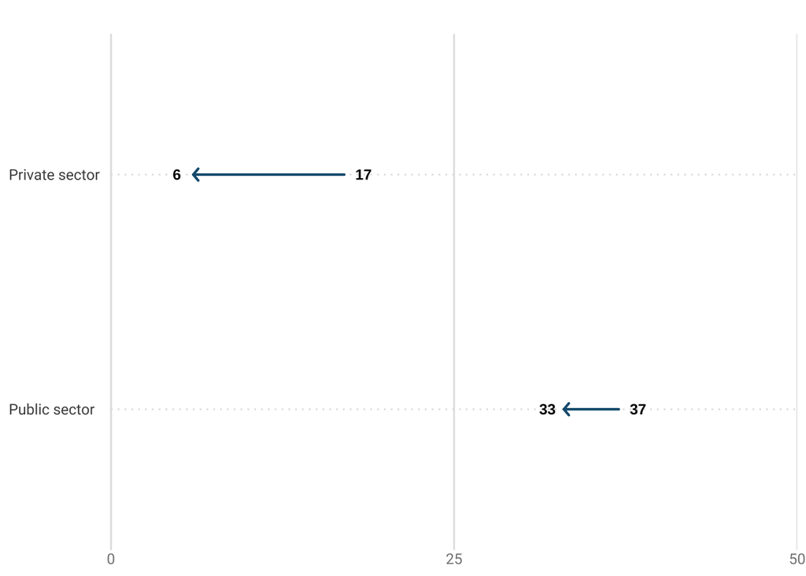

```r
# create sector plot
sectors_plot <- ggplot(data = sectors) +
  geom_segment(aes(x = union_1983, xend = union_2022, y = group),
               arrow = arrow(angle = 50,
                             length = unit(0.17, "cm")),
               color = "#155c7e",
               linewidth = 0.75,
               lineend = "round") +
  geom_text(aes(x = union_1983 + 1.4, y = group, label = union_1983),
            size = 3.25,
            fontface = "bold") +
  geom_text(aes(x = union_2022 - 1.2, y = group, label = union_2022),
            size = 3.25,
            fontface = "bold") +
  scale_x_continuous(limits = c(0, 50),
                     breaks = c(0, 25, 50),
                     expand = c(0, 0)) +
  labs(title = "BY SECTOR") +
  theme(text = element_text(family = "Roboto"),
        plot.title = element_text(hjust = -0.535,
                                  size = 11,
                                  face = "bold"),
        axis.ticks = element_blank(),
        axis.title = element_blank(),
        axis.text.x = element_text(size = 9.25,
                                   color = "#848484"),
        axis.text.y = element_text(margin = margin(r = 7, unit = "pt"),
                                   hjust = 0,
                                   size = 9.25),
        axis.line.y = element_line(color = "#e1e1e1"),
        panel.background = element_blank(),
        panel.grid.major.x = element_line(color = "#e1e1e1"),
        panel.grid.major.y = element_line(color = "#e1e1e1",
                                          linewidth = 0.5,
                                          linetype = 3))

sectors_plot
```

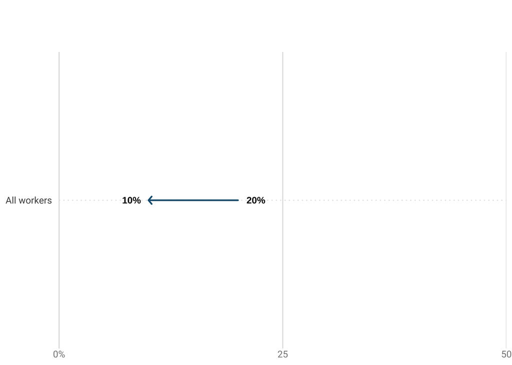

```r
# create all workers plot
all_workers_plot <- ggplot(data = all_workers) +
  geom_segment(aes(x = union_1983, xend = union_2022, y = group),
               arrow = arrow(angle = 50,
                             length = unit(0.17, "cm")),
               color = "#155c7e",
               linewidth = 0.75,
               lineend = "round") +
  geom_text(aes(x = union_1983 + 2, y = group, label = text_1983),
            size = 3.25,
            fontface = "bold") +
  geom_text(aes(x = union_2022 - 1.9, y = group, label = text_2022),
            size = 3.25,
            fontface = "bold") +
  scale_x_continuous(limits = c(0, 50),
                     breaks = c(0, 25, 50),
                     expand = c(0, 0),
                     labels = c("0%", "25", "50")) +
  labs(title = "Union membership has fallen sharply over the past four decades",
       subtitle = "Share of the work force in a union, by industry") +
  theme(text = element_text(family = "Roboto"),
        plot.title = element_text(hjust = 12.155,
                                  size = 12,
                                  face = "bold"),
        plot.subtitle = element_text(hjust = -1.11,
                                     size = 10,
                                     color = "#848484",
                                     margin = margin(b = 20, unit = "pt")),
        axis.ticks = element_blank(),
        axis.title = element_blank(),
        axis.text.x = element_text(size = 9.25,
                                   color = "#848484"),
        axis.text.y = element_text(margin = margin(r = 7, unit = "pt"),
                                   hjust = 0,
                                   size = 9.25),
        axis.line.y = element_line(color = "#e1e1e1"),
        panel.background = element_blank(),
        panel.grid.major.x = element_line(color = "#e1e1e1"),
        panel.grid.major.y = element_line(color = "#e1e1e1",
                                          linewidth = 0.5,
                                          linetype = 3))

all_workers_plot
```

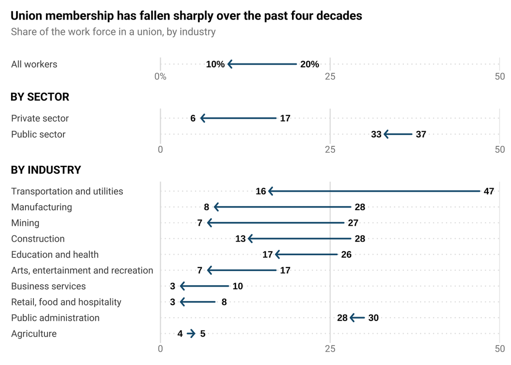

```r
# merge plots together into one larger plot
all_workers_plot / sectors_plot / industries_plot +
  plot_layout(nrow = 3, heights = c(0.9, 2.4, 11))
```

## Resources Reflection (required)

List the resources you used to help with this assignment then write 3-5 sentence reflection on which resources were most helpful in finishing this task.

**Resources:**

- https://r-statistics.co/Top50-Ggplot2-Visualizations-MasterList-R-Code.html#6.%20Change
- https://tibble.tidyverse.org
- https://stackoverflow.com/questions/71777528/how-to-filter-not-in
- https://r-graph-gallery.com/415-arrows-in-ggplot-graph.html
- https://stackoverflow.com/questions/75976913/edit-the-space-between-axis-ticks-and-axis-labels-in-ggplot
- Amin’s office hours
- Google search for “NYT Times visualization” which lead me to use the Roboto font and learn that they probably do their viz in DataWrapper (cannot find original links)

**Reflection:**

The R-Statistics article featuring nearly all types of plots was immensely helpful in getting started and realizing that I was looking for geom_segment(). Various documentation websites were also helpful in understanding how to use different functions, and I Googled to learn more about NYT’s viz to try to emulate it better. Lastly, Amin’s office hours were ultimately the most helpful, because I could ask specific questions and get feedback (and be forced to try something I thought wouldn’t work, but it did :)).